# Worksheet 4 - Scientific Visualisation MVE080/MMG640

## Uncertainty and storytelling with data

Name: *Houshi He*

1. It describes the tasks.
2. It (sometimes) provides coding templates that you can use as a basis for your own code.
3. It is a template also for the report that you upload in Canvas.

The tasks are of various types: some are to read some text and then comment on it (no coding), and some are about creating visualisations using plotnine. Once you have done finished all the tasks, export this document as an HTML file and upload it in Canvas. You are encouraged to discuss problems and solutions with your fellow students, but each student must solve all tasks by themselves and hand-in their own report. Notice that Jupyter notebooks use [Markdown](https://docs.github.com/en/github/writing-on-github/getting-started-with-writing-and-formatting-on-github/basic-writing-and-formatting-syntax#links) for writing text cells. Make sure you understand the basics.

The below loads the packages required for this homework.

```python
import numpy as np
import pandas as pd
import geopandas as gpd
from plotnine import *
# Currently in a plotine dependancy they have deprication warning, so
# we mute warnings to have a better experience
import warnings
warnings.filterwarnings("ignore")

# A nice color palette for categorical data
cbPalette = ["#E69F00", "#56B4E9", "#009E73",
             "#F0E442", "#0072B2", "#D55E00",
             "#CC79A7", "#999999"]
```

## Task 1

Read Chapter 16 of [Fundamentals of Data Visualizations](https://clauswilke.com/dataviz/), then answer the questions below.

### Question 1.1

During Lecture 6, we visualised uncertainty for point estimates using i) graded error bars and ii) fuzziness (slide 7). Briefly describe when each kind of visual is suitable.

### Answer 1.1

*Graded error-bars are suitable when you want to show the uncertainty around point estimates and assume the data is Gaussian. They work well for visualizing confidence intervals or standard deviations.*

*Fuzziness is better for showing probabilities and uncertainty, especially when the data isn’t Gaussian. It's useful for conveying how likely different values are but not as good for showing confidence intervals or statistical significance.*

### Question 1.2

Another way to visualise uncertainty is a **Hypothetical outcome plots** (Chapter 16 in [Fundamentals of Data Visualizations](https://clauswilke.com/dataviz/)). Briefly describe the key features of such a visual.

### Answer 1.2

*Hypothetical Outcome Plots show probabilities by visualizing multiple possible outcomes. They give the reader a better sense of uncertainty compared to static plots or text. HOPs display a range of possible results, helping to convey how likely different outcomes are. The key is to use a sufficient number of outcomes to reduce bias or select outcomes that represent the entire dataset accurately.*

### Question 1.3

Often when doing regression (fitting a curve to data), we want to use the regression model to make predictions. What is important to think about when visualising model predictions?

### Answer 1.3

*When visualizing predictions, it's crucial to clearly distinguish between the actual data and the predicted points. Failing to do so can easily lead readers to misinterpret the plot and draw incorrect conclusions.*

## Uncertainty

For this part reading chapter 16 in [Fundamentals of Data Visualizations](https://clauswilke.com/dataviz/) can help.

### Question 2.1

Coffee is undoubtedly a popular beverage. On Canvas, I have uploaded a dataset with ratings for coffee beans from six different countries.

Here, we are interested in identifying which country on average has the best quality beans. Create two plots, where in i) you plot the mean ($\mu$) and standard deviation for each country (using error bars), and ii) where you plot the mean and standard error of the mean estimate. Briefly discuss the drawbacks with error bars.

As a reminder. For country $j$ with coffee ratings $x^{(j)}_1, \ldots, x^{(j)}_{n_j}$ the sample mean is given by

$$ \hat{\mu}^{(j)} = \sum_{i = 1}^{n_j} x_i^{(j)}, $$

sample standard deviation by

$$ \hat{\sigma}^{(j)} = \sqrt{\frac{1}{n - 1} \sum_{i = 1}^{n_j} (x_i^{(j)} - \hat{\mu}^{(j)})^2}, $$

and sample standard error for $\hat{\mu}^{(j)}$

$$ \hat{\sigma}_{\hat{\mu}^{(j)}} = \frac{\hat{\sigma}^{(j)}}{\sqrt{n}} $$

and a confidence interval with confidence level $1 - \alpha$ is given by;

$$ \hat{\mu}^{(j)} \pm t_{n-1}(1 - \alpha / 2) \hat{\sigma}_{\hat{\mu}^{(j)}} $$

where $t_{n-1}$ is the t-distribution with $n-1$ degree of freedom. For confidence level $1 - \alpha=0.95$ and $n = 30$ we have that $t_{29}(1 - 0.025) \approx 2.05$.

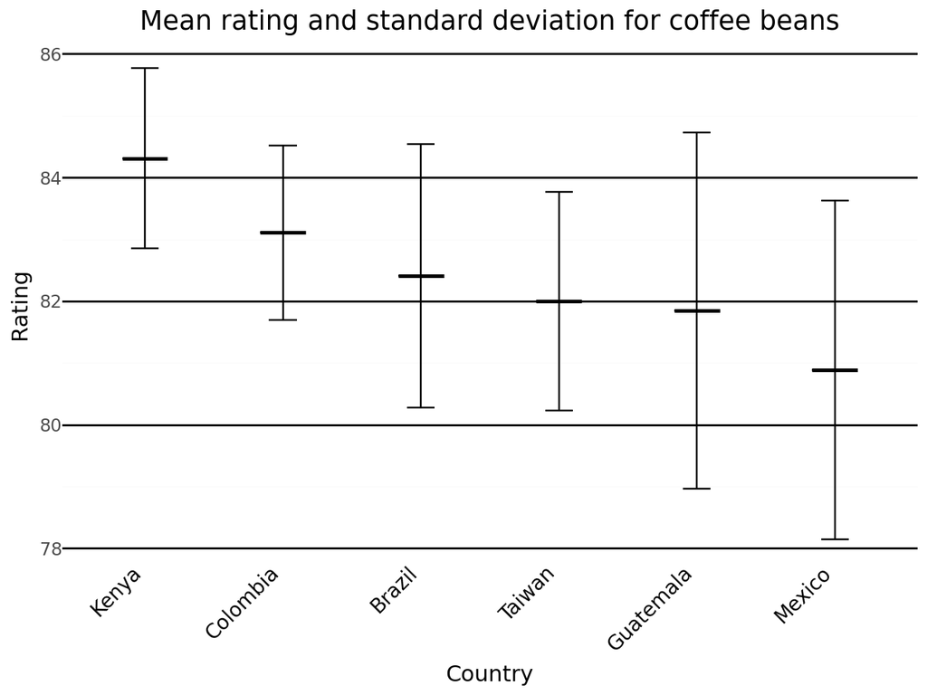

```python
# Insert code here for visual 1
# Read the coffee data
df_coffee = pd.read_csv('Coffee_tidy.csv')

# Compute summary statistics using groupby
df_summary = (
    df_coffee.groupby('country_of_origin', as_index=False)
    .agg(
        num_evals=('total_cup_points', 'size'),
        mean_rating=('total_cup_points', 'mean'),
        std_rating=('total_cup_points', 'std'),
    )
)

# Calculate standard error of the mean
df_summary['mean_ste'] = df_summary['std_rating'] / np.sqrt(df_summary['num_evals'])

# Sort data by mean rating in descending order
df_summary = df_summary.sort_values('mean_rating', ascending=False)

# Define the order for plotting
order = df_summary['country_of_origin']

# Plotting
plot = (
    ggplot(df_summary, aes('country_of_origin', 'mean_rating', ymin='mean_rating - std_rating', ymax='mean_rating + std_rating'))
    + geom_crossbar(aes(y='mean_rating', ymin='mean_rating', ymax='mean_rating'), width=0.33)  # Mean as a bar
    + geom_errorbar(width=0.2)  # Add error bars
    + scale_x_discrete(limits=order)  # Maintain sorted order
    + labs(x='Country', y='Rating', title='Mean rating and standard deviation for coffee beans')
    + theme_minimal()
    + theme(
        panel_grid_major_x=element_blank(),
        panel_grid_major_y=element_line(color='black', size=1),
        axis_text_x=element_text(color="black", size=10, rotation=45, hjust=1)  # Rotate x-axis labels for better readability
    )
)

# Display the plot
plot
# Remember to print the visual
```

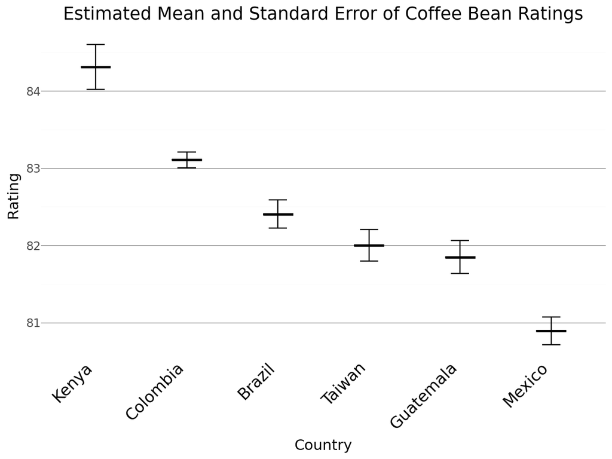

```python
# Insert code here for visual 2
# Read the coffee data
df_coffee = pd.read_csv('Coffee_tidy.csv')

# Compute summary statistics using groupby
df_summary = (
    df_coffee.groupby('country_of_origin', as_index=False)
    .agg(
        num_evals=('total_cup_points', 'size'),
        mean_rating=('total_cup_points', 'mean'),
        std_error=('total_cup_points', lambda x: x.std() / np.sqrt(len(x)))  # Calculate standard error
    )
)

# Sort data by mean rating in descending order
df_summary = df_summary.sort_values('mean_rating', ascending=False)

# Define the order for plotting
order = df_summary['country_of_origin']

# Plotting
plot = (
    ggplot(df_summary, aes('country_of_origin', 'mean_rating', ymax='mean_rating + std_error', ymin='mean_rating - std_error'))
    + geom_crossbar(aes(y='mean_rating', ymin='mean_rating', ymax='mean_rating'), width=0.33)  # Represent mean with a bar
    + geom_errorbar(width=0.2)  # Add error bars for standard error
    + scale_x_discrete(limits=order)  # Maintain sorted order
    + labs(x='Country', y='Rating', title='Estimated Mean and Standard Error of Coffee Bean Ratings')
    + theme_minimal()
    + theme(
        panel_grid_major_x=element_blank(),
        panel_grid_major_y=element_line(color='gray', size=0.5),
        axis_text_x=element_text(color="black", size=12, rotation=45, hjust=1)  # Rotate x-axis labels for better readability
    )
)

# Display the plot
plot
# Remember to print the visual
```

*Error bars have limitations as they assume the data is Gaussian and can be misleading when this isn’t true. They only show a range, like confidence intervals, without indicating the probability distribution. Overlapping bars can make it unclear whether differences are significant, and too many error bars can clutter the visualization.*

### Question 2.2

Now using the coffee dataset, visualise the uncertainty in the mean estimate using i) graded error bars (here, plot confidence intervals with 80%, 90% and 99% confidence) and ii) fuzzy error bars (as on slide 7 in Lecture 6).

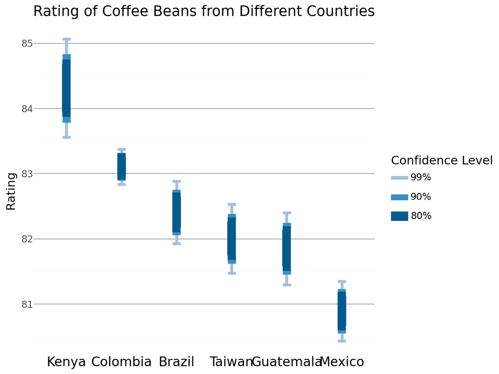

```python
# Insert code here for visual 1
# Compute stats for different confidence levels
confidence_levels = {"99%": 2.576, "90%": 1.645, "80%": 1.282}
stats_list = []

for ci_label, z_value in confidence_levels.items():
    stats = df_coffee.groupby("country_of_origin")["total_cup_points"].agg(mean="mean", sem="sem").reset_index()
    stats["ci_hi"] = stats["mean"] + z_value * stats["sem"]
    stats["ci_lo"] = stats["mean"] - z_value * stats["sem"]
    stats["ci_percent"] = ci_label
    stats_list.append(stats)

# Combine stats for all confidence levels
stats = pd.concat(stats_list, ignore_index=True)

# Ensure categorical ordering
stats["ci_percent"] = pd.Categorical(stats["ci_percent"], categories=["99%", "90%", "80%"], ordered=True)
stats["country_of_origin"] = pd.Categorical(stats["country_of_origin"], categories=order, ordered=True)

# Plotting
plot = (
    ggplot(stats, aes(x="country_of_origin"))
    + geom_errorbar(aes(ymin="ci_lo", ymax="ci_hi", color="ci_percent", size="ci_percent"), width=0.15)
    + scale_color_manual(values=["#a6bddb", "#3690c0", "#045a8d"], name="Confidence Level")
    + scale_size_manual(values=[1.5, 3.0, 4.5], name="Confidence Level")
    + scale_x_discrete(limits=order)
    + labs(x="", y="Rating", title="Rating of Coffee Beans from Different Countries")
    + theme_minimal()
    + theme(
        panel_grid_major_x=element_blank(),
        panel_grid_major_y=element_line(color="gray", size=0.5),
        axis_text_x=element_text(size=12, color="black"),
    )
)

plot
# Remember to print the visual
```

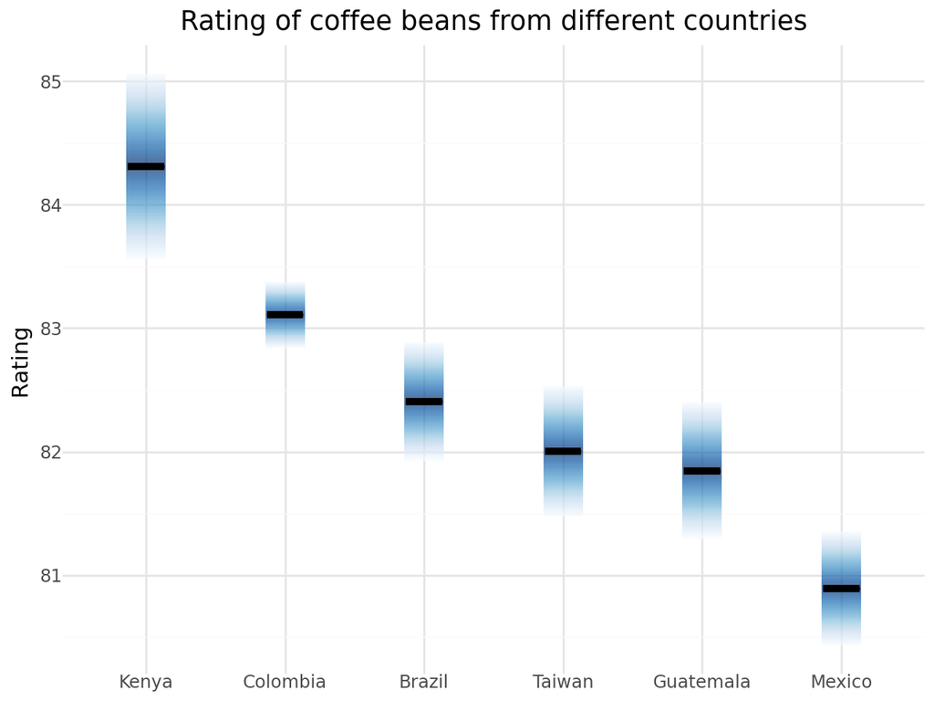

```python
# Insert code here for visual 2
# Filter data for the selected confidence level
confidence_level = "99%"
data_fuzzy_tmp = stats.query("ci_percent == @confidence_level")

# Generate data for fuzzy visualization
line_color = np.concatenate([np.linspace(0, 50, 50), np.linspace(50, 0, 50)])

def generate_fuzzy_data(row):
    val_min, val_max = row["ci_lo"], row["ci_hi"]
    return pd.DataFrame({
        "val_line": np.linspace(val_min, val_max, 100),
        "color_line": line_color,
        "country_of_origin": row["country_of_origin"]
    })

# Apply the function to each row and concatenate results
data_fuzzy = pd.concat(data_fuzzy_tmp.apply(generate_fuzzy_data, axis=1).tolist(), ignore_index=True)

# Plot
plot = (
    ggplot(data_fuzzy, aes("country_of_origin", "val_line"))
    + geom_line(aes(color="color_line"), size=11.0, alpha=0.7)
    + geom_crossbar(
        data=df_summary,
        mapping=aes(x="country_of_origin", y="mean_rating", ymin="mean_rating", ymax="mean_rating"),
        width=0.26, size=1.0
    )
    + scale_color_cmap("Blues")
    + labs(x="", y="Rating", title="Rating of coffee beans from different countries")
    + theme_minimal()
    + theme(legend_position="none")
    + scale_x_discrete(limits=order)
)

plot
# Remember to print the visual
```

### Question 2.3

Frequency graphs are a powerful tool for visualising probabilities. On Canvas, I have uploaded an image of such a graph. Recreate it (you do not have to recreate the colours perfectly). The figure might look strange when rendered in Jupyter (then, it is better to save it to disk and see how it looks like),

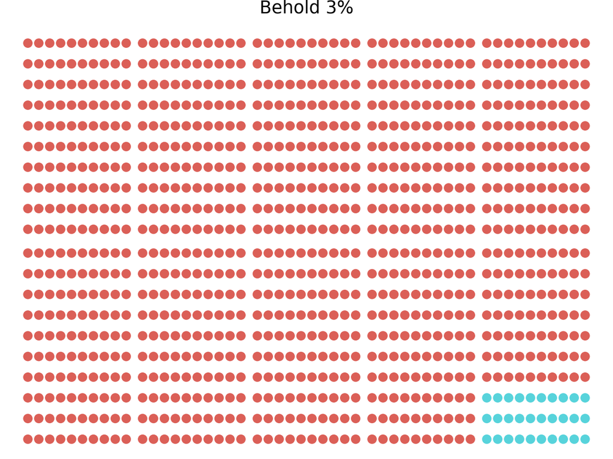

```python
# Insert code here
# Define color palette

# Create the grid for x and y coordinates (50 x 20 grid)
x_values = np.linspace(1, 50, 50)
y_values = np.linspace(1, 20, 20)
xx, yy = np.meshgrid(x_values, y_values)

# Flatten the 2D grid into 1D arrays
x_flat = np.reshape(xx, (-1,))
y_flat = np.reshape(yy, (-1,))

# Assign initial color categories (default is 0)
color_values = np.zeros_like(x_flat)

# Apply color condition (specific color for certain points)
color_values[(x_flat > 40) & (y_flat < 4)] = 1

# Apply transformations to x values (shift points based on their position)
x_flat[x_flat > 10] += 0.5
x_flat[x_flat > 21] += 0.5
x_flat[x_flat > 31] += 0.5
x_flat[x_flat > 42] += 0.5

# Apply transformation to y values (shift points based on their position)
y_flat[y_flat > 10] += 0.15

# Create DataFrame from coordinates and color information
coords_df = pd.DataFrame({'x': x_flat, 'y': y_flat, 'color': pd.Categorical(color_values)})

# Generate plot
plot = (
    ggplot(coords_df, aes('x', 'y', color='color'))
    + geom_point(show_legend=False, size=3)
    + labs(x='', y='', title='Behold 3%')
    + theme_void()  # Use a minimal theme without axes or grid
)

# Save and display the plot
plot
# Remember to print the visual
```

### Question 2.4

There are different ways to visualise curve fits. One is the fan plot (see lecture 6). On Canvas, I have uploaded a fan plot and associated dataset; use this dataset to recreate the visual.

**Note** - Hypothetical outcomes are generated via bootstraping, for computational speed it might be worthwhile to downsample the hypothetical outcomes.

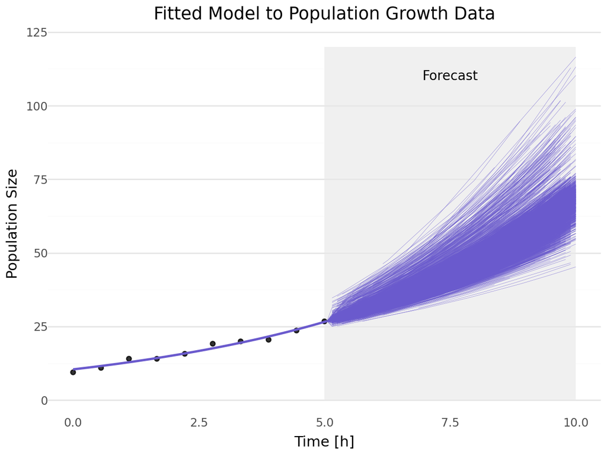

```python
# Insert code here
# Load the data
observed_data = pd.read_csv('Data_obs-1.csv')
fitted_data = pd.read_csv('Fit_fan.csv')
predicted_data = pd.read_csv('Pred_funnel.csv')

# Sample a smaller fraction of the predicted data for better performance
predicted_data_sampled = predicted_data.sample(frac=0.1, random_state=42)

# Create the plot
plot = (
    ggplot(fitted_data, aes(x='t', y='median')) +

    # Add shaded region to highlight forecast period
    geom_rect(aes(xmin=5.0, xmax=10.0, ymin=0.0, ymax=120.0), fill='#f0f0f0', alpha=0.1) +

    # Plot observed data points
    geom_point(data=observed_data, mapping=aes(x='t', y='N'), color='black', size=1.5, alpha=0.8) +

    # Plot the fitted model line
    geom_line(color='slateblue', size=1) +

    # Plot the predicted data with a smaller line size for visual clarity
    geom_line(
        data=predicted_data_sampled,
        mapping=aes(x='t', y='N_pred', group='index'),
        color='slateblue', size=0.1
    ) +

    # Add axis labels and title
    labs(
        x='Time [h]',
        y='Population Size',
        title='Fitted Model to Population Growth Data'
    ) +

    # Annotate the forecast section
    annotate("text", x=7.5, y=110, label="Forecast", size=10, color="black", ha="center") +

    # Apply minimal theme for cleaner aesthetics
    theme_minimal() +

    # Customize theme elements (e.g., remove grid lines on the x-axis)
    theme(
        legend_position="none",
        panel_grid_major_x=element_blank(),
        panel_grid_minor_x=element_blank()
    )
)

# Display the plot
plot
# Remember to print the visual
```